# All Features

This vignette walks through the advanced features of **panelforest** using a single clinical trial subgroup dataset. Each section introduces one feature and shows working code that produces a rendered plot.

## Data

```r
df <- data.frame(
  subgroup = c("Overall", "Age < 65", "Age >= 65",
               "Male", "Female", "ECOG 0", "ECOG 1-2"),
  n        = c(312L, 163L, 149L, 180L, 132L, 108L, 204L),
  events   = c(187L, 91L, 96L, 104L, 83L, 58L, 129L),
  HR       = c(0.68, 0.61, 0.76, 0.64, 0.74, 0.53, 0.76),
  LCI      = c(0.54, 0.44, 0.57, 0.47, 0.53, 0.34, 0.59),
  UCI      = c(0.85, 0.83, 1.01, 0.86, 1.04, 0.82, 0.98),
  pval     = c(0.001, 0.003, 0.062, 0.008, 0.098, 0.044, 0.012),
  resp_rate = c(0.42, 0.46, 0.38, 0.44, 0.40, 0.51, 0.38),
  mean_diff = c(-0.32, -0.41, -0.22, -0.36, -0.27, -0.48, -0.25),
  lci_diff  = c(-0.55, -0.68, -0.46, -0.60, -0.52, -0.75, -0.48),
  uci_diff  = c(-0.09,  -0.14, 0.02, -0.12, 0.02, -0.21, -0.02),
  stringsAsFactors = FALSE
)
```

## 1 Log-scale CI panel with axis

When plotting hazard ratios the x-axis should be on a log scale. Set `trans = "log"`, supply explicit `xlim` and `breaks`, enable the axis with `show_axis = TRUE`, and label it with `axis_label`. The reference line at 1 (no effect) is drawn automatically via `ref_line = 1`.

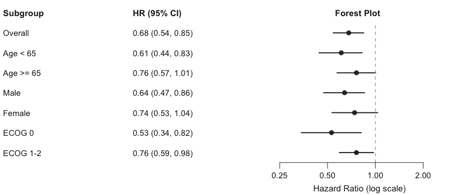

```r
p1 <- forest_plot(df) |>
  add_text("subgroup", header = "Subgroup", width = 2) |>
  add_text_ci("HR", "LCI", "UCI", header = "HR (95% CI)", width = 2) |>
  add_ci("HR", "LCI", "UCI",
    trans      = "log",
    xlim       = c(0.2, 3),
    breaks     = c(0.25, 0.5, 1, 2),
    show_axis  = TRUE,
    axis_label = "Hazard Ratio (log scale)",
    ref_line   = 1,
    header     = "Forest Plot"
  )

size <- fp_size(p1)
fp_render(p1)
```

Key parameters:

| Parameter | Role |
| --- | --- |
| `trans = "log"` | Log10 scale for the x-axis |
| `xlim` | Sets both the visible axis range and the truncation boundary |
| `breaks` | Explicit tick positions (must be positive) |
| `show_axis = TRUE` | Renders the x-axis below the CI panel |
| `axis_label` | Text printed under the axis |
| `ref_line` | Vertical reference line (must be > 0 on log scale) |

## 2 Truncation arrows

When a confidence interval whisker extends beyond `xlim` panelforest draws an arrow rather than an impossible whisker. By default the truncation boundary equals `xlim`. Use the separate `truncate` argument when you want the axis to show a wider range but still clip CIs to a narrower window.

Arrow appearance is controlled by three parameters:

- `arrow_length` — arrowhead size in inches (default `0.08`)
- `arrow_type` — `"open"` or `"closed"` (default `"closed"`)
- `arrow_angle` — half-angle of the arrowhead in degrees (default `30`)

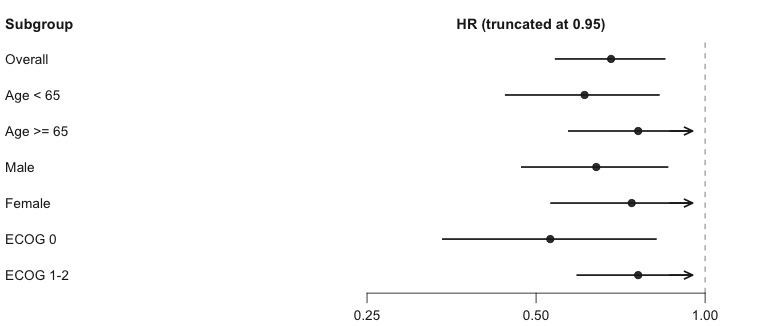

```r
# Age >= 65 and Female have UCI > 1 — their upper whiskers will be clipped
# at 0.95 while the axis still shows up to 1.2.
p2 <- forest_plot(df) |>
  add_text("subgroup", header = "Subgroup", width = 2) |>
  add_ci("HR", "LCI", "UCI",
    trans        = "log",
    xlim         = c(0.2, 1.2),
    truncate     = c(0.2, 0.95),
    breaks       = c(0.25, 0.5, 1),
    show_axis    = TRUE,
    ref_line     = 1,
    header       = "HR (truncated at 0.95)",
    arrow_length = 0.1,
    arrow_type   = "open",
    arrow_angle  = 25
  )

fp_render(p2)
```

`xlim = c(0.2, 1.2)` defines the full axis extent. `truncate = c(0.2, 0.95)` clips the CI whiskers more aggressively — any upper bound above 0.95 is replaced by an outward-pointing arrow.

## 3 Favors annotations

`favors_left` and `favors_right` add directional labels and arrows below the CI panel. They are typically paired with `show_axis = TRUE`. `favors_span` (0–1) controls how far the arrows extend from the reference line, and `favors_gap` adds space between the arrow origin and the reference line.

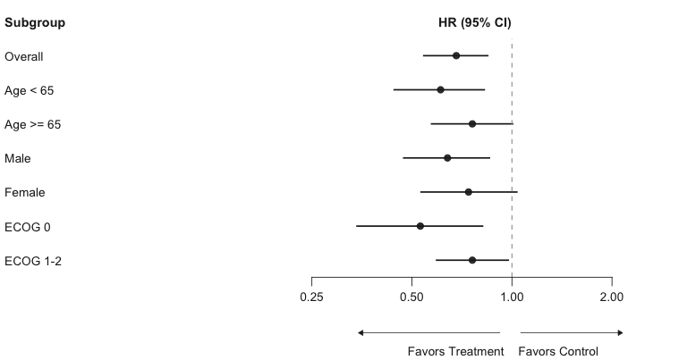

```r
p3 <- forest_plot(df) |>
  add_text("subgroup", header = "Subgroup", width = 2) |>
  add_ci("HR", "LCI", "UCI",
    trans         = "log",
    xlim          = c(0.2, 3),
    breaks        = c(0.25, 0.5, 1, 2),
    ref_line      = 1,
    show_axis     = TRUE,
    axis_label    = "Hazard Ratio",
    favors_left   = "Favors Treatment",
    favors_right  = "Favors Control",
    favors_span   = 0.65,
    favors_gap    = 0.05,
    header        = "HR (95% CI)"
  )

fp_render(p3)
```

`favors_gap = 0.05` leaves a small gap around the reference line so the arrowheads do not overlap the dashed ref line. Set `favors_gap = FALSE` (the default) to start arrows exactly at the reference line.

## 4 `fp_aes` — map data columns to visual properties

`fp_aes()` maps column names in the data frame to aesthetic properties of CI points or text labels. Every value in the named column is applied to the corresponding row.

Supported aesthetics for `add_ci()`: `colour`, `fill`, `alpha`, `glyph`, `shape`, `point_size`, `line_width`.

Supported aesthetics for `add_text()`: `colour`, `fontface`, `size`.

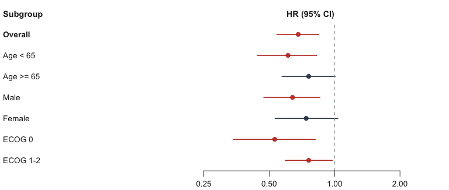

```r
df_aes <- df
df_aes$ci_colour <- ifelse(df$pval < 0.05, "#c0392b", "#2c3e50")
df_aes$ci_fill   <- ifelse(df$pval < 0.05, "#e74c3c", "#7f8c8d")
df_aes$lbl_face  <- ifelse(df$subgroup == "Overall", "bold", "plain")

p4 <- forest_plot(df_aes) |>
  add_text("subgroup",
    header  = "Subgroup",
    width   = 2,
    mapping = fp_aes(fontface = "lbl_face")
  ) |>
  add_ci("HR", "LCI", "UCI",
    trans    = "log",
    xlim     = c(0.2, 3),
    breaks   = c(0.25, 0.5, 1, 2),
    ref_line = 1,
    show_axis = TRUE,
    header   = "HR (95% CI)",
    mapping  = fp_aes(colour = "ci_colour", fill = "ci_fill")
  )

fp_render(p4)
```

Rows with p < 0.05 are highlighted in red; the “Overall” row is bold. The `fp_aes()` object simply stores column names as strings — the builder resolves each name at render time.

## 5 `add_header_group` — spanning header rows

`add_header_group()` places a label that spans multiple adjacent panels in a row above the regular column headers. Panels are identified by their 1-based position in the chain of `add_*()` calls.

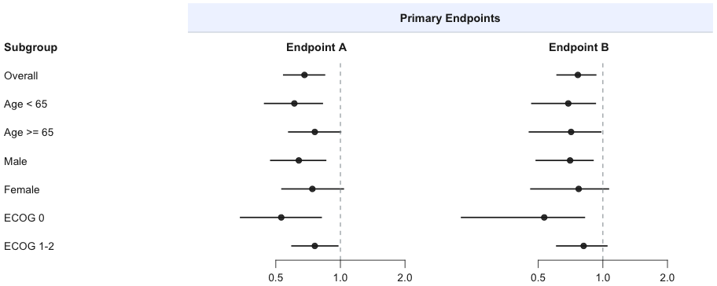

```r
df2 <- df
df2$HR2  <- df$HR  * runif(7, 0.85, 1.15)
df2$LCI2 <- df$LCI * runif(7, 0.85, 1.15)
df2$UCI2 <- df$UCI * runif(7, 0.85, 1.15)

set.seed(42)
df2$HR2  <- df$HR  * runif(7, 0.85, 1.15)
df2$LCI2 <- pmax(df2$HR2 - (df$UCI - df$HR) * runif(7, 0.9, 1.1), 0.1)
df2$UCI2 <- df2$HR2 + (df$UCI - df$HR) * runif(7, 0.9, 1.1)

p5 <- forest_plot(df2) |>
  add_text("subgroup", header = "Subgroup", width = 2) |>             # panel 1
  add_gap(width = 0.1) |>                                              # panel 2
  add_ci("HR",  "LCI",  "UCI",                                        # panel 3
    trans = "log", xlim = c(0.2, 3), breaks = c(0.5, 1, 2),
    ref_line = 1, show_axis = TRUE, header = "Endpoint A") |>
  add_ci("HR2", "LCI2", "UCI2",                                       # panel 4
    trans = "log", xlim = c(0.2, 3), breaks = c(0.5, 1, 2),
    ref_line = 1, show_axis = TRUE, header = "Endpoint B") |>
  add_header_group("Primary Endpoints", panels = 3:4,
    background = "#f0f4ff", border = TRUE)

fp_render(p5)
```

`panels = 3:4` spans the two CI panels. The `background` fill and `border` line visually group the columns. `panels` must be contiguous integers.

## 6 Custom panels with `fp_custom`

`fp_custom()` accepts an arbitrary `plot_fn` that receives the data frame and theme, then returns a ggplot. The y-axis must span `1` to `n_rows` using the same coordinate space as the built-in panels (row 1 is the top row in the coordinate system after layout, i.e., `rev(seq_len(n_rows))`).

[figure not shown]

```r
pval_panel <- fp_custom(
  plot_fn = function(data, n_rows, theme) {
    df_p <- data.frame(
      x     = 0.5,
      y     = rev(seq_len(n_rows)),
      label = ifelse(
        is.na(data$pval), "",
        ifelse(data$pval < 0.001, "< 0.001",
               sprintf("%.3f", data$pval))
      )
    )
    ggplot(df_p, aes(x = x, y = y, label = label)) +
      geom_text(
        size   = theme$text_size,
        colour = theme$text_colour,
        family = theme$base_family
      ) +
      scale_x_continuous(limits = c(0, 1), expand = expansion(0)) +
      theme_void()
  },
  header = "P-value",
  width  = 1.2
)

p6 <- forest_plot(df) |>
  add_text("subgroup", header = "Subgroup", width = 2) |>
  add_ci("HR", "LCI", "UCI",
    trans = "log", xlim = c(0.2, 3), breaks = c(0.25, 0.5, 1, 2),
    ref_line = 1, show_axis = TRUE, header = "HR (95% CI)") |>
  add_custom(pval_panel)

fp_render(p6)
```

The `plot_fn` signature is flexible: declare only the parameters you need (`data`, `n_rows`, `row_heights`, `theme`, `spec`). panelforest passes each by name, so order does not matter. The function must return a ggplot.

## 7 Formatter helpers

Three built-in formatters transform numeric columns to display strings without storing pre-formatted text in the data frame.

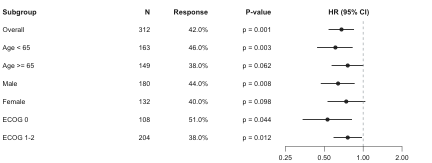

| Formatter | Formats | Key arguments |
| --- | --- | --- |
| `fp_fmt_number()` | General numeric | `digits`, `big_mark`, `prefix`, `suffix` |
| `fp_fmt_percent()` | Proportion → percentage | `digits`, `scale` (default 100), `suffix` |
| `fp_fmt_pvalue()` | P-values with threshold | `digits`, `threshold`, `prefix` |

```r
p7 <- forest_plot(df) |>
  add_text("subgroup", header = "Subgroup", width = 2) |>
  add_text("n",
    header    = "N",
    width     = 0.8,
    align     = "right",
    formatter = fp_fmt_number(digits = 0, big_mark = ",")
  ) |>
  add_text("resp_rate",
    header    = "Response",
    width     = 1.1,
    align     = "right",
    formatter = fp_fmt_percent(digits = 1)
  ) |>
  add_text("pval",
    header    = "P-value",
    width     = 1.2,
    align     = "right",
    formatter = fp_fmt_pvalue(digits = 3, threshold = 0.001)
  ) |>
  add_ci("HR", "LCI", "UCI",
    trans = "log", xlim = c(0.2, 3), breaks = c(0.25, 0.5, 1, 2),
    ref_line = 1, show_axis = TRUE, header = "HR (95% CI)")

fp_render(p7)
```

`NA` values are always replaced with the `na` argument (default `""`).

## 8 `fp_register` — extending the rendering pipeline

panelforest dispatches rendering through a type registry. Each spec type (`"text"`, `"ci"`, `"dot"`, etc.) maps to a builder function. `fp_register()` lets you override a built-in builder or introduce an entirely new type.

The most common use-case is wrapping a built-in builder with pre/post processing. Here we override `"ci"` to always set a minimum line width:

```r
original_ci_builder <- getFromNamespace(".build_ci", "panelforest")

my_ci_builder <- function(ctx, spec, cell_edits) {
  spec$line_width <- max(spec$line_width, 0.8)
  original_ci_builder(ctx, spec, cell_edits)
}

fp_register("ci", my_ci_builder, overwrite = TRUE)

# Restore the default when done
fp_register("ci", original_ci_builder, overwrite = TRUE)
```

The same mechanism supports entirely new spec types: create a spec constructor that calls `.make_spec()` (from the package internals) with a unique `type` string, then register a builder for that string. Power users can pair `fp_custom()` with a wrapper spec for full control without touching the registry at all.

## 9 Dot panel

`add_dot()` is designed for continuous endpoints such as mean differences or standardised mean differences. It draws a point (with optional CI whiskers) on a linear or log scale.

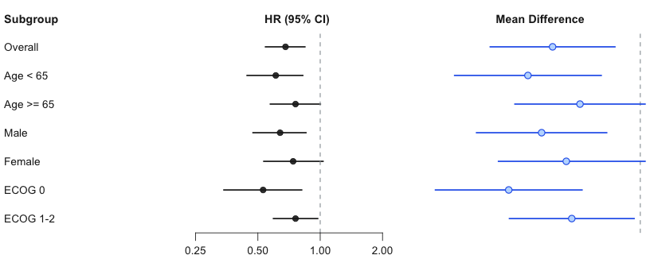

```r
p9 <- forest_plot(df) |>
  add_text("subgroup", header = "Subgroup", width = 2) |>
  add_ci("HR", "LCI", "UCI",
    trans = "log", xlim = c(0.2, 3), breaks = c(0.25, 0.5, 1, 2),
    ref_line = 1, show_axis = TRUE, header = "HR (95% CI)") |>
  add_gap(width = 0.1) |>
  add_dot("mean_diff",
    lower      = "lci_diff",
    upper      = "uci_diff",
    header     = "Mean Difference",
    ref_line   = 0,
    trans      = "identity",
    colour     = "#2563eb",
    shape      = 21,
    fill       = "#bfdbfe",
    point_size = 2.5,
    breaks     = c(-0.75, -0.5, -0.25, 0, 0.25)
  )

fp_render(p9)
```

`add_dot()` and `add_ci()` share the `ref_line`, `trans`, `truncate`, `breaks`, `colour`, `fill`, `shape`, and `point_size` parameters. The key difference is that `add_dot()` does not render glyphs (no diamond summary style) and does not support `show_axis` or `favors_*` annotations.

## 10 Spacer vs gap

Two spec types create visual white space between panels:

- `add_gap(width)` — proportional width, measured in the same relative units as the `width` arguments of other panels (e.g., `width = 0.15` is 15% of a “standard” panel width of 1.0).
- `add_spacer(width, unit)` — absolute width in any `grid::unit()` unit: `"mm"`, `"cm"`, `"in"`, or `"pt"`.

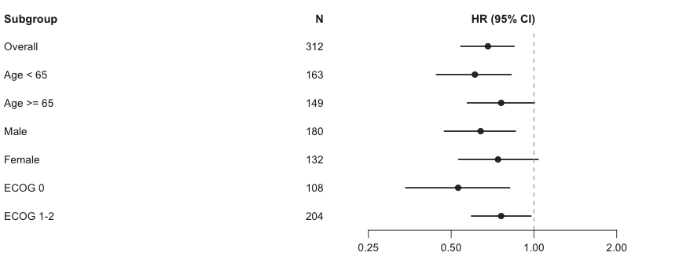

```r
p10 <- forest_plot(df) |>
  add_text("subgroup", header = "Subgroup", width = 2) |>
  add_gap(width = 0.15) |>
  add_text("n", header = "N", width = 0.7, align = "right",
           formatter = fp_fmt_number(digits = 0)) |>
  add_spacer(width = 5, unit = "mm") |>
  add_ci("HR", "LCI", "UCI",
    trans = "log", xlim = c(0.2, 3), breaks = c(0.25, 0.5, 1, 2),
    ref_line = 1, show_axis = TRUE, header = "HR (95% CI)")

fp_render(p10)
```

Use `add_gap()` when you want space that scales with the plot width. Use `add_spacer()` when you need a precise, device-independent margin — for example to align a forest plot with a companion table produced at a fixed column width.

## 11 Multiple CI panels side by side

Two `add_ci()` calls produce two independent forest plot panels, each with its own scale, reference line, and axis. This is useful for comparing two endpoints or two subgroup analyses in a single figure.

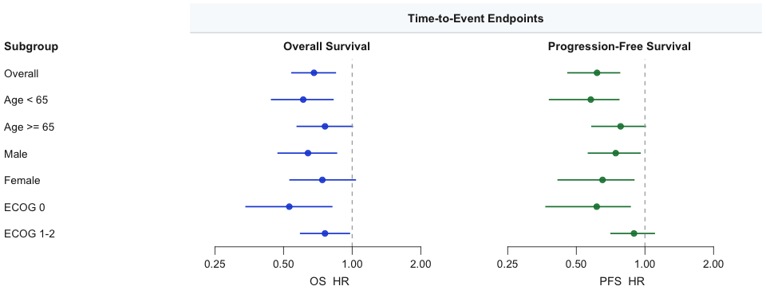

```r
set.seed(1)
df3 <- df
df3$HR_pfs  <- df$HR * runif(7, 0.80, 1.20)
df3$LCI_pfs <- pmax(df3$HR_pfs - (df$UCI - df$LCI) / 2 * runif(7, 0.9, 1.1), 0.1)
df3$UCI_pfs <- df3$HR_pfs + (df$UCI - df$LCI) / 2 * runif(7, 0.9, 1.1)

p11 <- forest_plot(df3) |>
  add_text("subgroup", header = "Subgroup", width = 2) |>
  add_ci("HR", "LCI", "UCI",
    trans     = "log",
    xlim      = c(0.2, 3),
    breaks    = c(0.25, 0.5, 1, 2),
    ref_line  = 1,
    show_axis = TRUE,
    axis_label = "OS  HR",
    header    = "Overall Survival",
    colour    = "#1d4ed8"
  ) |>
  add_gap(width = 0.15) |>
  add_ci("HR_pfs", "LCI_pfs", "UCI_pfs",
    trans     = "log",
    xlim      = c(0.2, 3),
    breaks    = c(0.25, 0.5, 1, 2),
    ref_line  = 1,
    show_axis = TRUE,
    axis_label = "PFS  HR",
    header    = "Progression-Free Survival",
    colour    = "#15803d"
  ) |>
  add_header_group("Time-to-Event Endpoints", panels = 2:4,
    background = "#f8fafc", border = TRUE)

fp_render(p11)
```

Each CI panel is fully independent: different colours, separate axes, and separate header labels. A `add_header_group()` spans both CI panels (and the gap between them) to create a grouped header tier.

## Putting it all together

The following example combines multiple advanced features — `fp_aes()`, `add_header_group()`, a custom panel, formatters, and favors annotations — into a single publication-style figure.

[figure not shown]

```r
df_full <- df
df_full$ci_colour <- ifelse(df$pval < 0.05, "#991b1b", "#374151")
df_full$lbl_face  <- ifelse(df$subgroup == "Overall", "bold", "plain")

sig_panel <- fp_custom(
  plot_fn = function(data, n_rows, theme) {
    df_s <- data.frame(
      x     = 0.5,
      y     = rev(seq_len(n_rows)),
      label = ifelse(data$pval < 0.05, "*", "")
    )
    ggplot(df_s, aes(x = x, y = y, label = label)) +
      geom_text(size = theme$text_size * 1.4, colour = "#c0392b",
                family = theme$base_family) +
      scale_x_continuous(limits = c(0, 1), expand = expansion(0)) +
      theme_void()
  },
  header = "",
  width  = 0.4
)

p_full <- forest_plot(df_full) |>
  add_text("subgroup",
    header  = "Subgroup",
    width   = 2,
    mapping = fp_aes(fontface = "lbl_face")
  ) |>
  add_text("n",
    header    = "N",
    width     = 0.7,
    align     = "right",
    formatter = fp_fmt_number(digits = 0, big_mark = ",")
  ) |>
  add_text("resp_rate",
    header    = "Response",
    width     = 1.1,
    align     = "right",
    formatter = fp_fmt_percent(digits = 1)
  ) |>
  add_gap(width = 0.12) |>
  add_ci("HR", "LCI", "UCI",
    trans         = "log",
    xlim          = c(0.2, 3),
    breaks        = c(0.25, 0.5, 1, 2),
    ref_line      = 1,
    show_axis     = TRUE,
    axis_label    = "Hazard Ratio (log scale)",
    favors_left   = "Favors Treatment",
    favors_right  = "Favors Control",
    favors_span   = 0.60,
    favors_gap    = 0.06,
    header        = "HR (95% CI)",
    mapping       = fp_aes(colour = "ci_colour")
  ) |>
  add_text("pval",
    header    = "P-value",
    width     = 1.2,
    align     = "right",
    formatter = fp_fmt_pvalue(digits = 3, threshold = 0.001)
  ) |>
  add_custom(sig_panel) |>
  add_header_group("Summary Statistics", panels = 2:3,
    background = "#f0fdf4", border = TRUE) |>
  add_header_group("Efficacy", panels = 5:7,
    background = "#eff6ff", border = TRUE)

fp_render(p_full)
```

This figure demonstrates:

- Per-row colour via `fp_aes()` (red for significant subgroups)
- Bold formatting for the overall row via `fp_aes(fontface = ...)`
- `fp_fmt_number()` and `fp_fmt_percent()` for compact display
- `fp_fmt_pvalue()` with a `< 0.001` threshold
- A custom significance-star panel via `fp_custom()`
- Two spanning header groups via `add_header_group()`
- `favors_left` / `favors_right` annotations with a gap